# Metabarcoding

Ramón Gallego

2023-10-27

## Metabarcoding analisis

Como vimos en clase, uno de los usos más importantes de los estudios de ADN ambiental son los de metabarcoding, en los que a partir de una muestra que contiene ADN de muchas especies se amplifica una parte del ADN que nos permita identificar las especies presentes.

El análisis de estos datos conlleva muchos pasos, en distinto orden, para pasar de las secuencias de ADN que obtenemos (aquí vamos a usar datos de Illumina MiSeq) al objetivo último de nuestro estudio (ya sea variación de las comunidades en el espacio o tiempo, listado de especies…).

Aquí tenemos un diagrama del workflow típico de estos estudios

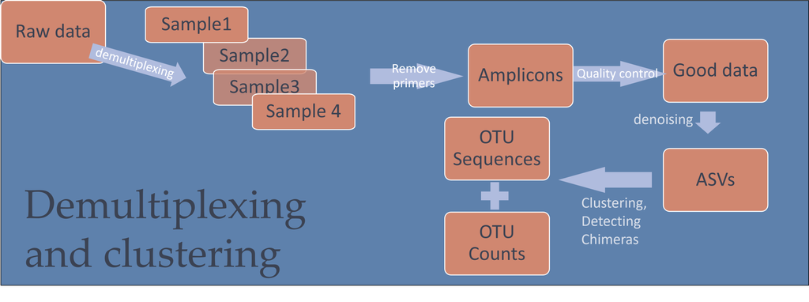

workflow

Por otra parte, lo que nos interesa no es las OTUs (Operational Taxonomical Units) sino la identidad taxonomica de esas secuencias

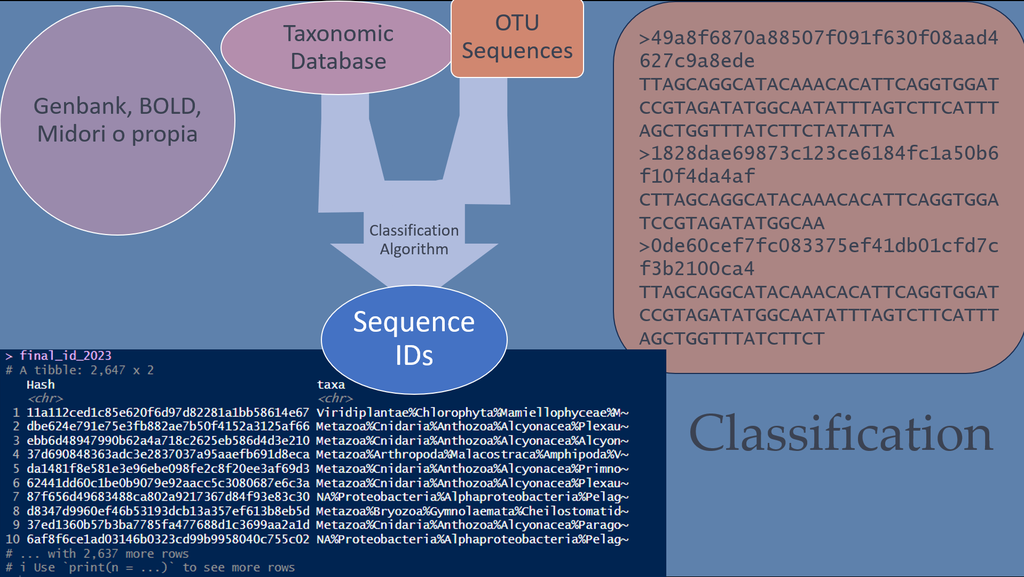

Empecemos por el formato de los datos en bruto o raw.

Lo que normalmente recibimos es una pareja de archivos por cada experimento de secuencición. Estos archivos (R1 y R2) corresponden a las secuencias estimadas desde el cada uno de sus extremos del las secuencias

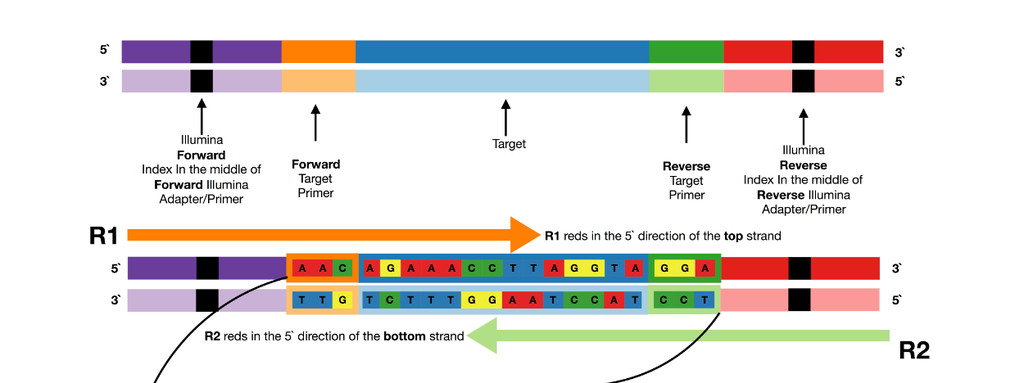

clas

### Demultiplexing

El coste de la secuenciación, unido a que estas tecnologías producen más datos de los que se necesitan para caracterizar una muestra, hace que sea práctica común unir muchas muestras en cada experimento. Cada muestra se prepara uniendi unos identificadores o barcodes al principio y final de cada secuencia. Luego usamos un programa para separar los archivos iniciales en varios archivos, una pareja R1 y R2 por cada muestra.

Hay veces que el servicio de secuenciación realiza este paso para nosotros, y otras veces que lo tenemos que hacer.

El programa que usamos es cutadapt, que se usa desde la linea de comandos y que usa la lista de barcodes para buscarlos en las secuencias y dividir los archivos iniciales en varias parejas.

En este ejemplo, ya lo hemos hecho.

Vamos a ver qué archivos tenemos con el comando `list.files()`, mirando en el directorio en el que tenemos los datos (`/data`)

```r
list.files(path = "data")
```

```
##  [1] "Annotated.hashes - copia.csv"
##  [2] "Annotated.hashes.csv"
##  [3] "ASV_table_all_together - copia.csv"
##  [4] "ASV_table_all_together.csv"
##  [5] "by.taxa.dataset.metadata - copia.csv"
##  [6] "by.taxa.dataset.metadata.csv"
##  [7] "Final_metadata - copia.csv"
##  [8] "Final_metadata.csv"
##  [9] "site.info - copia.csv"
## [10] "site.info.csv"
## [11] "unique.sp_collapse - copia.csv"
## [12] "unique.sp_collapse.csv"
```